# ICDS User Guide

## 4 Example: Obtain subpathways

For a priori KEGG path, we perform a greedy algorithm to search for interested subpathways.We provide two statistical test methods of the subpathway, which one is whole gene-based perturbation, and the other is the local gene perturbation in a particular pathway.

```r
#obtain z-score of each gene
zzz<-GetExampleData("zzz")
zzz[1:10,]
```

|  | padjust | z_score | exp.p | meth.p | cnv.p |
| --- | --- | --- | --- | --- | --- |
| AACS | 1.4985665228349e-12 | 6.97785849233781 | 4.27591802855694e-05 | 3.79351155555026e-07 | 0.000154005933715148 |
| AASDHPPT | 3.59090577618182e-09 | 5.78661689489162 | 1.51758714809107e-05 | 0.138052336368975 | 4.95190895519194e-06 |
| ACAA1 | 2.26766115435345e-06 | 4.58520914055579 | 0.00254706069215554 | 4.80814465758352e-06 | 1 |
| ACACA | 7.81825182198368e-05 | 3.78073660442176 | 0.0414461349050663 | 1.62339209249856e-05 | 1 |
| ACACB | 3.17474389450549e-24 | 10.0863369031681 | 1.0796730435591e-25 | 0.152770581756488 | 0.0979253199784077 |
| ACAD8 | 8.80185318920443e-08 | 5.22301085773967 | 2.21022111058924e-05 | 0.19898879195769 | 7.67894501521561e-05 |
| ACADL | 6.14820533862155e-54 | 15.4184802326598 | 2.63073053599382e-55 | 0.00265801159320894 | 1 |
| ACAT1 | 1.1545332900424e-06 | 4.72430235586153 | 6.58517201812735e-06 | 0.287245454170909 | 0.00305344462196611 |
| ACER1 | 2.96364608769913e-06 | 4.5289664035691 | 1 | 1.65137200042873e-08 | 1 |
| ACER3 | 1.63555761386473e-07 | 5.10711682637474 | 5.9116689567922e-07 | 0.00112767915011995 | 1 |

```r
require(graphite)
zz<-GetExampleData("zzz")
#subpathdata<-FindSubPath(zz) #only show
```

Optimize interested subpathways.If the number of genes shared by the two pathways accounted for more than the Overlap ratio of each pathway genes,than combine two pathways.

```r
subpathdata<-GetExampleData("subpathdata")
keysubpathways<-opt_subpath(subpathdata,zz,overlap=0.6)
head(keysubpathways)
```

```
##      SubpathwayID  pathway
## [1,] "path00010_1" "Glycolysis / Gluconeogenesis"
## [2,] "path00010_2" "Glycolysis / Gluconeogenesis"
## [3,] "path00010_3" "Glycolysis / Gluconeogenesis"
## [4,] "path00010_4" "Glycolysis / Gluconeogenesis"
## [5,] "path00010_5" "Glycolysis / Gluconeogenesis"
## [6,] "path00010_6" "Glycolysis / Gluconeogenesis"
##      Subgene
## [1,] "G6PC/HK3/PGM1/HKDC1/GPI/FBP1/ALDOA/G6PC2/GALM/G6PC3"
## [2,] "ADH5/ADH1B/ADH1A/ALDH3B2/ALDH2/AKR1A1/ALDH7A1/ALDH3B1/ALDH1B1/ALDH1A3"
## [3,] "PKLR/ENO1/LDHA/PGAM1/MINPP1/PCK1/LDHAL6A/LDHAL6B"
## [4,] "ACSS1/ALDH3B2/ADH1B/ADH1A/ALDH2/DLAT/ACSS2"
## [5,] "PFKP/ALDOA/GAPDH/FBP1/GPI/ALDOC/GAPDHS"
## [6,] "PGAM4/ENO1/PGAM1/MINPP1/PCK1/PGK2"
##      Size SubpathwayZScore
## [1,] "10" "20.8492758044976"
## [2,] "10" "20.9317587858665"
## [3,] "8"  "19.0899605586423"
## [4,] "7"  "19.7078248333379"
## [5,] "7"  "18.3020024323356"
## [6,] "6"  "16.7772761794305"
```

the perturbation test was used to calculate statistical significance for these interested subpathways.

```r
keysubpathways<-Permutation(keysubpathways,zz,nperm1=100,method1=TRUE,nperm2=100,method2=FALSE)
head(keysubpathways)
```

```
##      SubpathwayID  pathway
## [1,] "path00010_1" "Glycolysis / Gluconeogenesis"
## [2,] "path00010_2" "Glycolysis / Gluconeogenesis"
## [3,] "path00010_3" "Glycolysis / Gluconeogenesis"
## [4,] "path00010_4" "Glycolysis / Gluconeogenesis"
## [5,] "path00010_5" "Glycolysis / Gluconeogenesis"
## [6,] "path00010_6" "Glycolysis / Gluconeogenesis"
##      Subgene
## [1,] "G6PC/HK3/PGM1/HKDC1/GPI/FBP1/ALDOA/G6PC2/GALM/G6PC3"
## [2,] "ADH5/ADH1B/ADH1A/ALDH3B2/ALDH2/AKR1A1/ALDH7A1/ALDH3B1/ALDH1B1/ALDH1A3"
## [3,] "PKLR/ENO1/LDHA/PGAM1/MINPP1/PCK1/LDHAL6A/LDHAL6B"
## [4,] "ACSS1/ALDH3B2/ADH1B/ADH1A/ALDH2/DLAT/ACSS2"
## [5,] "PFKP/ALDOA/GAPDH/FBP1/GPI/ALDOC/GAPDHS"
## [6,] "PGAM4/ENO1/PGAM1/MINPP1/PCK1/PGK2"
##      Size SubpathwayZScore   p1     fdr1
## [1,] "10" "20.8492758044976" "0.05" "0.365714285714286"
## [2,] "10" "20.9317587858665" "0.08" "0.465454545454545"
## [3,] "8"  "19.0899605586423" "0.05" "0.365714285714286"
## [4,] "7"  "19.7078248333379" "0.01" "0.150588235294118"
## [5,] "7"  "18.3020024323356" "0.08" "0.465454545454545"
## [6,] "6"  "16.7772761794305" "0.07" "0.448"
```

## 4 Example: plot a network graph when user input a list of gene

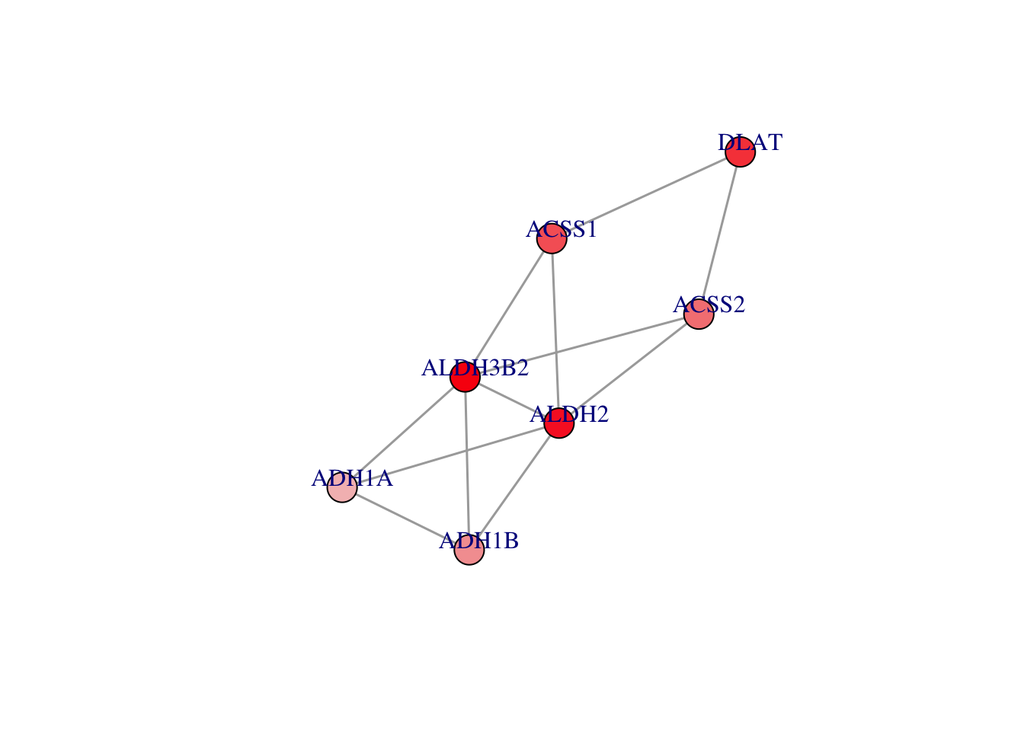

```r
require(graphite)
require(org.Hs.eg.db)
subpID<-unlist(strsplit("ACSS1/ALDH3B2/ADH1B/ADH1A/ALDH2/DLAT/ACSS2","/"))
pathway.name="Glycolysis / Gluconeogenesis"
zzz<- GetExampleData("zzz")
PlotSubpathway(subpID=subpID,pathway.name=pathway.name,zz=zzz)
```